# P1_DAND

March 12, 2016

In this project, We will investigate a classic phenomenon from experimental psychology called the Stroop Effect.

## VARIABLES IN EXPERIMENT

```r
df <- read.csv("stroopdata.csv")
colnames(df)
```

```
## [1] "Congruent"   "Incongruent"
```

```r
summary(df)
```

```
##    Congruent      Incongruent
##  Min.   : 8.63   Min.   :15.69
##  1st Qu.:11.90   1st Qu.:18.72
##  Median :14.36   Median :21.02
##  Mean   :14.05   Mean   :22.02
##  3rd Qu.:16.20   3rd Qu.:24.05
##  Max.   :22.33   Max.   :35.26
```

### INDEPENDENT VARIABLE

- categorical variable to determine type of word (congruent/incongruent)

### DEPENDENT VARIABLE

- Response time to name ink color

## HYPOTHESIS OF EXPERIMENT

We want to check if there is significant difference in time taken for naming color between congruent and incongruent variables.  
mean(congruent) <- mean time taken for identifying color of congruent words for population.  
mean(Incongruent) <- mean time taken for identifying color of incongruent words for population.

### NULL HYPOTHESIS

Response time is independent of type of variable  
mean(congruent) = mean(Incongruent)

### ALTERNATIVE HYPOTHESIS

Response time is dependant on type of variable  
mean(congruent) < mean(Incongruent) or  
mean(congruent) > mean(Incongruent)

### PROPOSED STATISTICAL TEST

We would use 2 tail paired t-test to accept or reject NULL hypothesis, defined by formula  
t-statistic = [mean(congruent) - mean(Incongruent)]/(standard deviation of difference in 2 categories)

We choose significance threshold i.e.  
alpha critical value = 0.05 (95%)

Rationale for using T test is  
- we have less than 30 samples  
- we don’t know population standard deviation

Though while doing T test, we have made assumption that data is normally distributed(Gaussian).

## DESCRIPTIVE STATISTICS

MEAN AND MEDIAN TIME TAKEN FOR IDENTIFYING INK ON CONGRUENT WORDS:

```r
mean(df$Congruent)
```

```
## [1] 14.05113
```

```r
median(df$Congruent)
```

```
## [1] 14.3565
```

MEAN AND MEDIAN TIME TAKEN FOR IDENTIFYING INK ON INCONGRUENT WORDS:

```r
mean(df$Incongruent)
```

```
## [1] 22.01592
```

```r
median(df$Incongruent)
```

```
## [1] 21.0175
```

VARIANCE AND STD OF TIME TAKEN FOR IDENTIFYING INK ON CONGRUENT WORDS:

```r
var(df$Congruent)
```

```
## [1] 12.66903
```

```r
sd(df$Congruent)
```

```
## [1] 3.559358
```

VARIANCE AND STD OF TIME TAKEN FOR IDENTIFYING INK ON INCONGRUENT WORDS:

```r
var(df$Incongruent)
```

```
## [1] 23.01176
```

```r
sd(df$Incongruent)
```

```
## [1] 4.797057
```

## VISUALIZATIONS

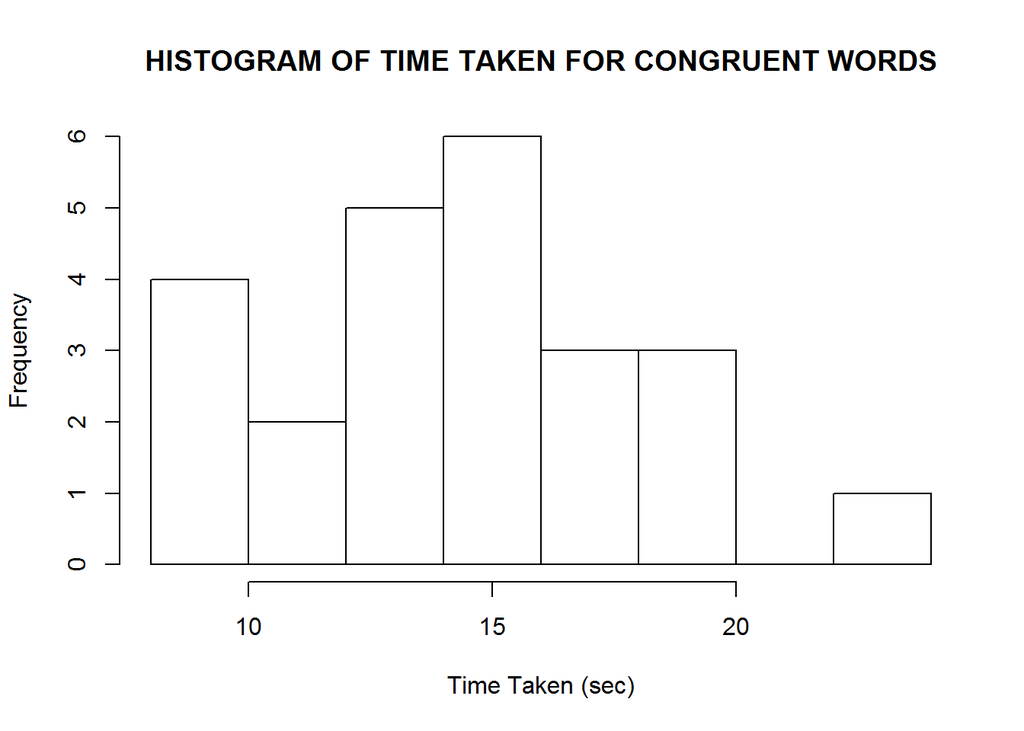

```r
hist(df$Congruent, main = "HISTOGRAM OF TIME TAKEN FOR CONGRUENT WORDS", xlab = "Time Taken (sec)")
```

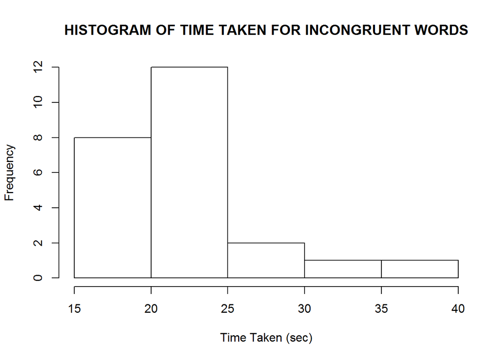

```r
hist(df$Incongruent, main = "HISTOGRAM OF TIME TAKEN FOR INCONGRUENT WORDS", xlab = "Time Taken (sec)")
```

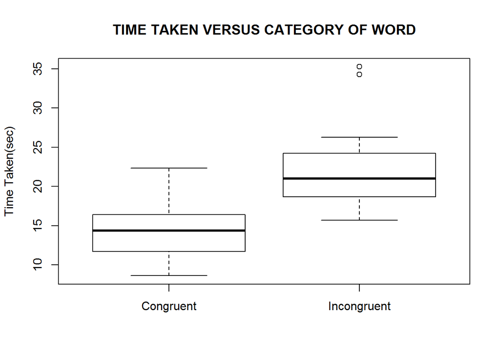

```r
boxplot(df, ylab = "Time Taken(sec)", main="TIME TAKEN VERSUS CATEGORY OF WORD")
```

## STASTICAL TEST

```r
t.test(df$Congruent,df$Incongruent, paired = TRUE)
```

```
##
##  Paired t-test
##
## data:  df$Congruent and df$Incongruent
## t = -8.0207, df = 23, p-value = 4.103e-08
## alternative hypothesis: true difference in means is not equal to 0
## 95 percent confidence interval:
##  -10.019028  -5.910555
## sample estimates:
## mean of the differences
##               -7.964792
```

```r
qt(0.975,23)
```

```
## [1] 2.068658
```

We see that T-test statistic of our paired T-test is less than critical value. Thus there is significant difference in response time for congruent and incongruent words. In fact response time for congruent word is signficantly less than incongruent words.  
We reject NULL hypothesis. Our confidence interval for mean difference is (-10.019028,-5.910555).  
This is as per our expectations from visualization of data.

## DETAILED INVESTIGATIONS

There are several theories to explain stroop effect mentioned in wikipedia. Some of these are:-

- Processing Speed  
  lag in brain’s ability to recognize color
- Selective attention  
  color recognition requires more attention

There are several variations of stroop effect like:-

- Warped Words  
  Here words are printed in distorted way making it difficult to read.
- Numerical  
  Here is incongruency between number and its size thus 5 is shown in smaller size than 3.